# Predictive Model for Household Financial Health Platform

MELISSA OGWAYO

2025-03-05

## Overview

The platform predicts household financial stability using income, employment, health, and household structure. It helps anticipate financial distress using socio-economic and financial data.

**Target Variable:**  
- `jkl_fihhmnnet1_dv` (Net Household Monthly Income)

**Predictors:**  
- Employment status  
- Health status  
- Household composition  
- Tenure type  
- Location  
- Socio-economic class

## 1. Data Preparation

### Load Dataset

```r
data <- read.csv("/Users/mellogwayo/Desktop/Household Financial Health Analytics Platform/data/processed/transformed_variables.csv")

# View the first few rows of the data
head(data)
```

```
##       pidp jkl_hidp j_hidp k_hidp   l_hidp jkl_pno jkl_mnpno jkl_fnpno
## 1 68008847 68013622    -14    -14 68013622       1 not in hh not in hh
## 2 68010887 68027222    -14    -14 68027222       1 not in hh not in hh
## 3 68068082 68027222    -14    -14 68027222       2 not in hh not in hh
## 4 68031967 68081622    -14    -14 68081622       1 not in hh not in hh
## 5 68036727 68095222    -14    -14 68095222       1 not in hh not in hh
## 6 68037407 68102022    -14    -14 68102022       1 not in hh not in hh
##      jkl_mnpid    jkl_fnpid jkl_mnspno jkl_fnspno   jkl_mnspid   jkl_fnspid
## 1 inapplicable inapplicable  not in hh  not in hh inapplicable inapplicable
## 2 inapplicable inapplicable  not in hh  not in hh inapplicable inapplicable
## 3 inapplicable inapplicable  not in hh  not in hh inapplicable inapplicable
## 4 inapplicable inapplicable  not in hh  not in hh inapplicable inapplicable
## 5 inapplicable inapplicable  not in hh  not in hh inapplicable inapplicable
## 6 inapplicable inapplicable  not in hh  not in hh inapplicable inapplicable
##   jkl_grmpno jkl_grfpno jkl_childpno jkl_country    jkl_gor_dv jkl_urban_dv
```

[output cut: 55 more lines]

##2. Initial data cleaning

### Check Data Structure

```r
str(data)
```

```
## 'data.frame':    19040 obs. of  35 variables:
##  $ pidp             : int  68008847 68010887 68068082 68031967 68036727 68037407 68041487 68041491 68043527 68044887 ...
##  $ jkl_hidp         : int  68013622 68027222 68027222 68081622 68095222 68102022 68115622 68115622 68129222 68142822 ...
##  $ j_hidp           : int  -14 -14 -14 -14 -14 -14 -14 -14 -14 -14 ...
##  $ k_hidp           : int  -14 -14 -14 -14 -14 -14 -14 -14 -14 -14 ...
##  $ l_hidp           : int  68013622 68027222 68027222 68081622 68095222 68102022 68115622 68115622 68129222 68142822 ...
##  $ jkl_pno          : int  1 1 2 1 1 1 1 2 1 1 ...
##  $ jkl_mnpno        : chr  "not in hh" "not in hh" "not in hh" "not in hh" ...
##  $ jkl_fnpno        : chr  "not in hh" "not in hh" "not in hh" "not in hh" ...
##  $ jkl_mnpid        : chr  "inapplicable" "inapplicable" "inapplicable" "inapplicable" ...
##  $ jkl_fnpid        : chr  "inapplicable" "inapplicable" "inapplicable" "inapplicable" ...
##  $ jkl_mnspno       : chr  "not in hh" "not in hh" "not in hh" "not in hh" ...
##  $ jkl_fnspno       : chr  "not in hh" "not in hh" "not in hh" "not in hh" ...
##  $ jkl_mnspid       : chr  "inapplicable" "inapplicable" "inapplicable" "inapplicable" ...
##  $ jkl_fnspid       : chr  "inapplicable" "inapplicable" "inapplicable" "inapplicable" ...
```

[output cut: 21 more lines]

```r
summary(data)
```

```
##       pidp              jkl_hidp             j_hidp
##  Min.   :5.998e+05   Min.   :6.801e+07   Min.   :       -14
##  1st Qu.:3.675e+08   1st Qu.:3.469e+08   1st Qu.:       -14
##  Median :7.083e+08   Median :6.873e+08   Median :       -14
##  Mean   :7.710e+08   Mean   :7.708e+08   Mean   :  40823901
##  3rd Qu.:1.157e+09   3rd Qu.:1.158e+09   3rd Qu.:       -14
##  Max.   :1.653e+09   Max.   :1.638e+09   Max.   :1638126818
##      k_hidp               l_hidp             jkl_pno        jkl_mnpno
##  Min.   :       -14   Min.   :      -14   Min.   : 1.000   Length:19040
##  1st Qu.:       -14   1st Qu.:      -14   1st Qu.: 1.000   Class :character
##  Median :       -14   Median :139022622   Median : 1.000   Mode  :character
##  Mean   : 485998506   Mean   :243959456   Mean   : 1.361
##  3rd Qu.:1090402120   3rd Qu.:478142022   3rd Qu.: 2.000
##  Max.   :1637766420   Max.   :823738422   Max.   :12.000
##   jkl_fnpno          jkl_mnpid          jkl_fnpid          jkl_mnspno
##  Length:19040       Length:19040       Length:19040       Length:19040
##  Class :character   Class :character   Class :character   Class :character
##  Mode  :character   Mode  :character   Mode  :character   Mode  :character
##
##
##
##   jkl_fnspno         jkl_mnspid         jkl_fnspid         jkl_grmpno
##  Length:19040       Length:19040       Length:19040       Length:19040
##  Class :character   Class :character   Class :character   Class :character
##  Mode  :character   Mode  :character   Mode  :character   Mode  :character
##
##
##
##   jkl_grfpno        jkl_childpno       jkl_country         jkl_gor_dv
##  Length:19040       Length:19040       Length:19040       Length:19040
##  Class :character   Class :character   Class :character   Class :character
##  Mode  :character   Mode  :character   Mode  :character   Mode  :character
##
##
##
##  jkl_urban_dv        jkl_sex_dv        jkl_mastat_dv       jkl_jbstat
##  Length:19040       Length:19040       Length:19040       Length:19040
##  Class :character   Class :character   Class :character   Class :character
##  Mode  :character   Mode  :character   Mode  :character   Mode  :character
##
```

[output cut: 8 more lines]

```
##
##  jkl_jbnssec5_dv    jkl_jbnssec3_dv    jkl_fimnnet_dv      jkl_health
##  Length:19040       Length:19040       Min.   : -5589.5   Length:19040
##  Class :character   Class :character   1st Qu.:   937.7   Class :character
##  Mode  :character   Mode  :character   Median :  1485.0   Mode  :character
##                                        Mean   :  1727.6
##                                        3rd Qu.:  2166.7
##                                        Max.   :102890.9
##  jkl_nkids_dv       jkl_hhtype_dv      jkl_tenure_dv      jkl_fihhmnnet1_dv
##  Length:19040       Length:19040       Length:19040       Min.   : -3306
##  Class :character   Class :character   Class :character   1st Qu.:  1772
##  Mode  :character   Mode  :character   Mode  :character   Median :  2831
##                                                           Mean   :  3369
##                                                           3rd Qu.:  4318
##                                                           Max.   :104319
```

### Check Missing Values

```r
missing_values <- colSums(is.na(data))
print(missing_values[missing_values > 0])  # Shows columns with missing values
```

```
## named numeric(0)
```

From the result above it can be seen that all columns have zero missing values.

### Check Correlation Between Variables

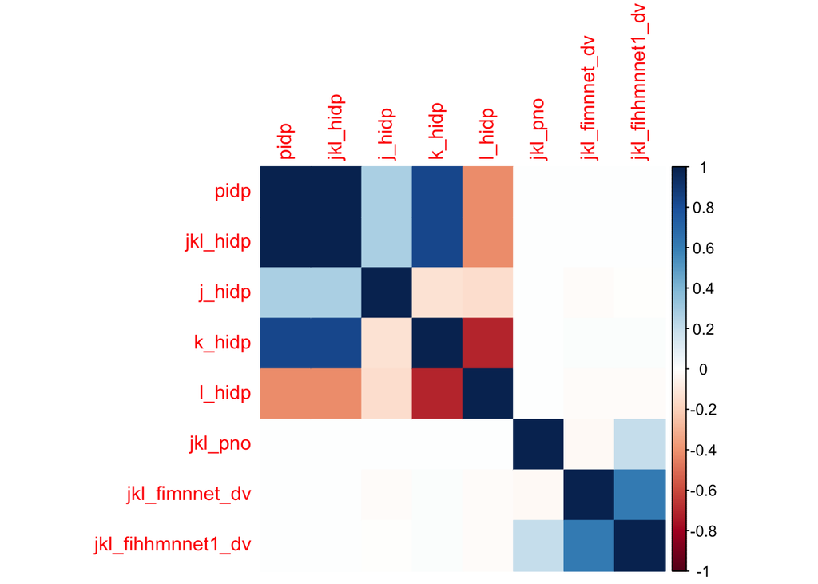

```r
library(corrplot)

cor_matrix <- cor(data %>% select_if(is.numeric), use = "complete.obs")
corrplot(cor_matrix, method = "color")
```

The correlation plot above shows relationships between different numerical variables in the dataset, with colors indicating the strength and direction of correlations. Dark blue represents strong positive correlations, white indicates no correlation, and dark red signifies strong negative correlations.

Notably, `jkl_fimnnet_dv` (individual net income) and `jkl_fihhmnnet1_dv` (household net income) exhibit a strong positive correlation, suggesting they are closely related and may introduce redundancy if both are included in the model. This is expected as both variables are representations of income.

Additionally, several `hidp` variables, likely household identifiers, show high correlations with each other, implying redundancy and limited predictive value. Some variables exhibit strong negative correlations, particularly among certain `hidp` variables, indicating inverse relationships. On the other hand, several variables have little to no correlation, meaning they might not be directly related or impactful in prediction.

Based on these findings, it would be beneficial to drop highly correlated features to prevent multicollinearity, use a Variance Inflation Factor (VIF) test to further assess redundancy, and perform feature selection to refine the predictive model for household financial health. This is why only one income variable `jkl_fihhmnnet1_dv` which represents the Net Household Monthly Income was used as the target variable. None of the household identifier variables were used in the construction of the predictin model.

```
##   jkl_fihhmnnet1_dv             jkl_jbstat jkl_health
## 1           2288.00 Paid employment(ft/pt)        Yes
## 2           4475.91 Paid employment(ft/pt)        Yes
## 3           4475.91          Self employed         No
## 4           1282.17                Retired        Yes
## 5           1456.17                Retired        Yes
## 6           2446.63 Paid employment(ft/pt)         No
##                                                     jkl_hhtype_dv
## 1                                  1 female, age 60+, no children
## 2                  Couple both under pensionable age, no children
## 3                  Couple both under pensionable age, no children
## 4                                  1 female, age 60+, no children
## 5                                   1 male, aged 65+, no children
## 6 2 adults, not a couple, both under pensionable age, no children
##                jkl_tenure_dv                                   jkl_ethn_dv
## 1        Owned with mortgage british/english/scottish/welsh/northern irish
## 2        Owned with mortgage british/english/scottish/welsh/northern irish
## 3        Owned with mortgage british/english/scottish/welsh/northern irish
## 4       Local authority rent british/english/scottish/welsh/northern irish
## 5                    missing british/english/scottish/welsh/northern irish
## 6 Rented private unfurnished british/english/scottish/welsh/northern irish
##      jkl_gor_dv jkl_sex_dv
## 1    North East     Female
## 2    North East     Female
## 3    North East       Male
## 4 West Midlands     Female
## 5    North East       Male
## 6    North East     Female
```

Each of these selcted features are significant determinant of household income. Their interplay determines financial stability, access to resources, and long-term wealth accumulation.

## 3. Model Training

### Model 1: Linear Regression

```
##
## Call:
## lm(formula = jkl_fihhmnnet1_dv ~ ., data = train)
##
## Residuals:
##    Min     1Q Median     3Q    Max
##  -8512  -1037   -288    608 100283
##
## Coefficients:
##                                                                                    Estimate
## (Intercept)                                                                          -68.98
## jkl_jbstatdon't know                                                                -117.80
## jkl_jbstatFamily care or home                                                         16.52
## jkl_jbstatFull-time student                                                          431.46
## jkl_jbstatGovt training scheme                                                      -784.20
## jkl_jbstatLT sick or disabled                                                        492.55
## jkl_jbstatOn apprenticeship                                                          419.36
## jkl_jbstatOn furlough                                                                426.46
## jkl_jbstatOn maternity leave                                                        1356.69
## jkl_jbstatPaid employment(ft/pt)                                                    1018.38
## jkl_jbstatrefusal                                                                   3304.35
## jkl_jbstatRetired                                                                    463.27
## jkl_jbstatSelf employed                                                              849.75
## jkl_jbstatTemporarily laid off/short term working                                    182.97
## jkl_jbstatUnemployed                                                                -477.95
## jkl_jbstatUnpaid, family business                                                    678.26
## jkl_healthNo                                                                          32.69
## jkl_healthrefusal                                                                   -501.82
## jkl_healthYes                                                                        -86.97
## jkl_hhtype_dv1 adult, 1 child                                                        415.37
## jkl_hhtype_dv1 adult, 2 or more children                                            1384.22
## jkl_hhtype_dv1 female, age 60+, no children                                          165.35
## jkl_hhtype_dv1 male, aged 65+, no children                                           405.18
## jkl_hhtype_dv2 adults, not a couple, 1 or more children                             1571.48
## jkl_hhtype_dv2 adults, not a couple, both under pensionable age, no children        1181.08
## jkl_hhtype_dv2 adults, not a couple, one or more over pensionable age, no children  1190.57
## jkl_hhtype_dv3 or more adults, 1 or more children, excl. any couples                3046.96
## jkl_hhtype_dv3 or more adults, 1-2 children, incl. at least one couple              3618.13
## jkl_hhtype_dv3 or more adults, no children, excl. any couples                       3066.90
## jkl_hhtype_dv3 or more adults, no children, incl. at least one couple               3406.09
```

[output cut: 340 more lines]

```
## jkl_gor_dvScotland
## jkl_gor_dvSouth East                                                               ***
## jkl_gor_dvSouth West
## jkl_gor_dvWales                                                                    *
## jkl_gor_dvWest Midlands
## jkl_gor_dvYorkshire and the Humber
## jkl_sex_dvinconsistent
## jkl_sex_dvMale
## jkl_sex_dvmissing
## ---
## Signif. codes:  0 '***' 0.001 '**' 0.01 '*' 0.05 '.' 0.1 ' ' 1
##
## Residual standard error: 2163 on 15158 degrees of freedom
## Multiple R-squared:  0.287,  Adjusted R-squared:  0.2835
## F-statistic: 82.43 on 74 and 15158 DF,  p-value: < 2.2e-16
```

### Model 2: Decision Tree

```
## n= 15233
##
## node), split, n, deviance, yval
##       * denotes terminal node
##
##  1) root 15233 99463460000 3363.204
##    2) jkl_hhtype_dv=1 adult under pensionable age, no children,1 adult, 1 child,1 female, age 60+, no children,1 male, aged 65+, no children,2 adults, not a couple, one or more over pensionable age, no children 4319  5910353000 1778.769 *
##    3) jkl_hhtype_dv=1 adult, 2 or more children,2 adults, not a couple, 1 or more children,2 adults, not a couple, both under pensionable age, no children,3 or more adults, 1 or more children, excl. any couples,3 or more adults, 1-2 children, incl. at least one couple,3 or more adults, no childre…
##      6) jkl_hhtype_dv=1 adult, 2 or more children,2 adults, not a couple, 1 or more children,2 adults, not a couple, both under pensionable age, no children,3 or more adults, 1 or more children, excl. any couples,Couple 1 or more over pensionable age,no children,Couple both under pensionable age,…
##       12) jkl_jbstat=Doing something else,don't know,Family care or home,Full-time student,Govt training scheme,LT sick or disabled,On apprenticeship,On furlough,On maternity leave,Retired,Temporarily laid off/short term working,Unemployed,Unpaid, family business 4335 14020840000 3096.744 *
##       13) jkl_jbstat=Paid employment(ft/pt),refusal,Self employed 3513 29069540000 3969.273 *
##      7) jkl_hhtype_dv=3 or more adults, 1-2 children, incl. at least one couple,3 or more adults, no children, excl. any couples,3 or more adults, no children, incl. at least one couple,Couple with 2 children 3066 26786810000 5277.476
##       14) jkl_gor_dv=East Midlands,East of England,North East,North West,Northern Ireland,Scotland,South West,Wales,West Midlands,Yorkshire and the Humber 2227 14285940000 4920.426 *
##       15) jkl_gor_dv=London,South East 839 11463370000 6225.213 *
```

### Model 3: Random Forest

```
##
## Call:
##  randomForest(formula = jkl_fihhmnnet1_dv ~ ., data = train, ntree = 500)
##                Type of random forest: regression
##                      Number of trees: 500
## No. of variables tried at each split: 2
##
##           Mean of squared residuals: 4725094
##                     % Var explained: 27.63
```

### Model 4: lightgbm

```r
#install.packages("janitor")
library(janitor)
library(caret)

# Clean column names to remove special characters
train <- train %>% clean_names()
test <- test %>% clean_names()

## One-Hot Encode Categorical Variables
# Create dummy variables
dummies <- dummyVars(" ~ .", data = train)

# Transform train and test sets
train_encoded <- predict(dummies, newdata = train) %>% as.data.frame()
test_encoded <- predict(dummies, newdata = test) %>% as.data.frame()

# Ensure column names are LightGBM-safe
colnames(train_encoded) <- make.names(colnames(train_encoded), unique = TRUE)
colnames(test_encoded) <- make.names(colnames(test_encoded), unique = TRUE)

# Convert to matrix format
train_matrix <- as.matrix(train_encoded)
test_matrix <- as.matrix(test_encoded)

# Prepare LightGBM dataset
dtrain <- lgb.Dataset(data = train_matrix, label = train$jkl_fihhmnnet1_dv)
dtest <- lgb.Dataset(data = test_matrix, label = test$jkl_fihhmnnet1_dv)

# Define LightGBM parameters
params <- list(
  objective = "regression",
  metric = "rmse",
  num_leaves = 31,
  learning_rate = 0.05
)

# Train LightGBM model
lgb_model <- lgb.train(params, dtrain, nrounds = 100)
```

```
## [LightGBM] [Info] Auto-choosing row-wise multi-threading, the overhead of testing was 0.001431 seconds.
## You can set `force_row_wise=true` to remove the overhead.
## And if memory is not enough, you can set `force_col_wise=true`.
## [LightGBM] [Info] Total Bins 391
## [LightGBM] [Info] Number of data points in the train set: 15233, number of used features: 69
## [LightGBM] [Info] Start training from score 3363.204145
```

```r
print(lgb_model)
```

```
## LightGBM Model (100 trees)
## Objective: regression
## Fitted to dataset with 82 columns
```

### Model 5: Elastic Net Regression

```r
# Convert to matrix
train_matrix <- as.matrix(train_encoded)
test_matrix <- as.matrix(test_encoded)

# Train Elastic Net with cross-validation
elastic_net_model <- cv.glmnet(train_matrix, train$jkl_fihhmnnet1_dv, alpha = 0.5)
print(elastic_net_model)
```

```
##
## Call:  cv.glmnet(x = train_matrix, y = train$jkl_fihhmnnet1_dv, alpha = 0.5)
##
## Measure: Mean-Squared Error
##
##     Lambda Index Measure    SE Nonzero
## min  77.68    46    5955 615.9       1
## 1se  77.68    46    5955 615.9       1
```

## 4. Model Evaluation

```
## Linear Regression RMSE:  2584.166
```

```
## Random Forest RMSE:  2573.834
```

```
## Decision Tree RMSE:  2637.515
```

```
## LightGBM RMSE:  1333.842
```

```
## Elastic Net RMSE:  87.63038
```